**After Data Cleaning**

```r
str(cor.data)
```

```
## 'data.frame':    994 obs. of  9 variables:
##  $ Age           : num  2 1 0 1 1 0 1 1 1 2 ...
##  $ Gender        : num  0 1 0 1 0 1 0 1 0 1 ...
##  $ OwnHome       : num  1 0 0 1 1 1 0 1 1 1 ...
##  $ Married       : num  0 0 0 1 0 1 0 0 1 1 ...
##  $ Salary        : int  47500 63600 13500 85600 68400 30400 48100 68400 51900 80700 ...
##  $ Children      : int  0 0 0 1 0 0 0 0 3 0 ...
##  $ Catalogs      : int  6 6 18 18 12 6 12 18 6 18 ...
##  $ AmountSpent   : int  755 1318 296 2436 1304 495 782 1155 158 3034 ...
##  $ Location_close: num  0 1 1 1 1 1 1 1 1 0 ...
```

**Observations from the Corelation matrix**  
1. Both Marriage and Salary, as well as, Money-Spent and Salary are highly correlated positively.  
2. Number of children and age are negatively correlated, in that dataset, older people have a small amount of children- either 0 or 1.  
3. Marriage and number of children are not correlated. Married and singles have about the same amount of children.  
4. No correlation is apparent between Gender and Age.

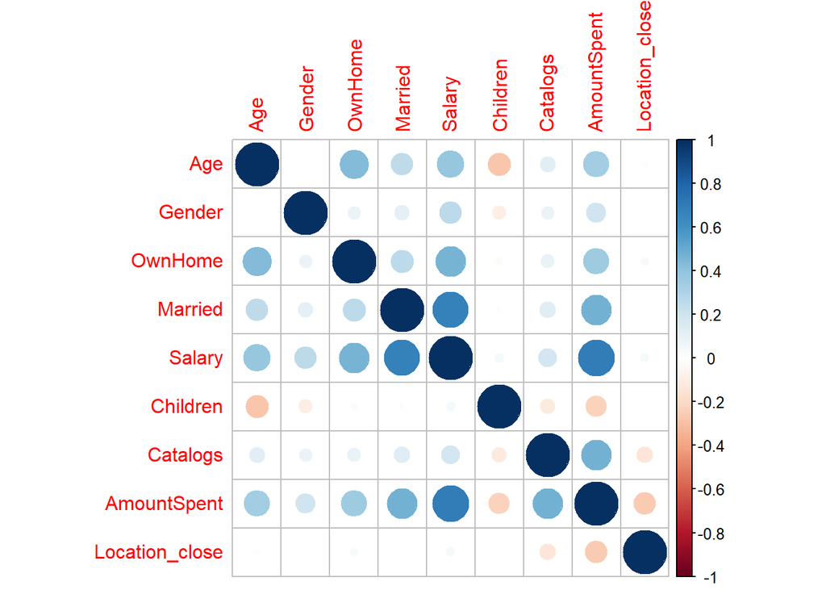

```r
cor.maxtrix<- cor(cor.data, method = "pearson", use = "complete.obs")

corrplot(cor.maxtrix)
```

```r
#explain the matrix, high correlation, low correlation etc.
```

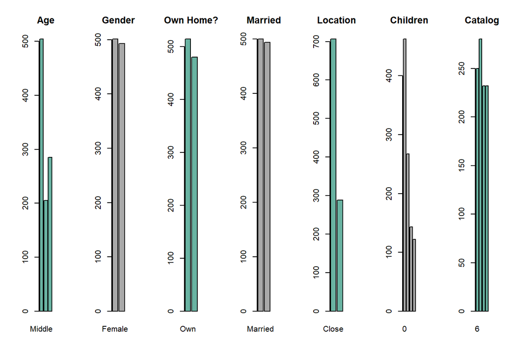

```r
library(ggplot2)

par(mfrow=c(1,7))

barplot(table(raw.data$Age), main="Age", col = "#69b3a2")
barplot(table(raw.data$Gender), main="Gender", col = "#A9A9A9")
barplot(table(raw.data$OwnHome), main="Own Home?", col = "#69b3a2")
barplot(table(raw.data$Married), main="Married", col = "#A9A9A9")
barplot(table(raw.data$Location), main="Location", col = "#69b3a2")
barplot(table(raw.data$Children), main="Children", col = "#A9A9A9")
barplot(table(raw.data$Catalog), main="Catalog", col = "#69b3a2")
```

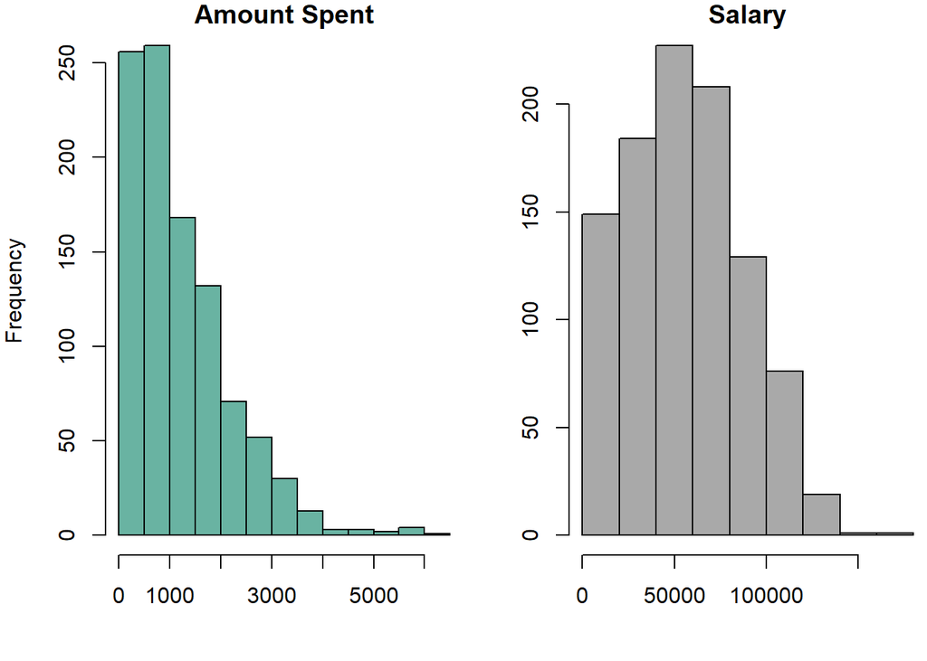

```r
par(
  mfrow=c(1,2),
  mar=c(4,4,1,0)
)
hist((raw.data$AmountSpent), xlab="", main="Amount Spent", col = "#69b3a2")
hist((raw.data$Salary), xlab="", ylab="", main="Salary", col = "#A9A9A9")
```

```r
#I will show the distribution of each categorical veriables
lapply( retail.df %>%
          select(c("Age", "Gender", "OwnHome", "Married", "Location", "Children", "History","Catalog"))
        ,table)
```

```
## $Age
##
## Middle    Old  Young
##    504    205    285
##
## $Gender
##
## Female   Male
##    501    493
##
## $OwnHome
##
##  Own Rent
##  514  480
##
## $Married
##
## Married  Single
##     500     494
##
## $Location
##
## Close   Far
##   706   288
##
## $Children
##
##   0   1   2   3
## 462 267 143 122
##
## $History
##
##    High     Low  Medium Unknown
##     254     229     211     300
##
## $Catalog
##
##      high_end high_midrange       low_end  low_midrange
##           232           232           250           280
```

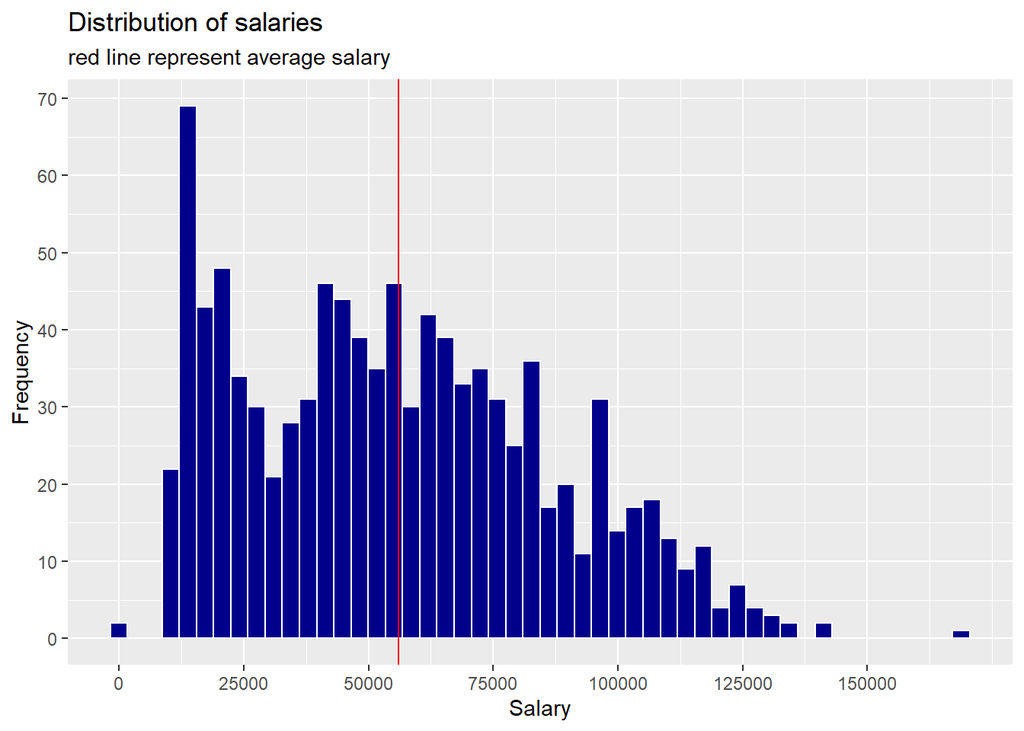

```r
ggplot(data = retail.df, aes(x = Salary))+
  geom_histogram(bins = 50, colour = 'white', fill = 'darkblue')+
  scale_x_continuous(breaks = seq(0,150000,25000))+
  scale_y_continuous(breaks = seq(0,70,10))+
  xlab("Salary")+
  ylab("Frequency")+
  ggtitle("Distribution of salaries")+
  geom_vline(xintercept = mean(retail.df$Salary), color = 'red')+
  labs(subtitle  = 'red line represent average salary')
```

*Salary distribution is skewed to the right, with an average salary of 56032.*

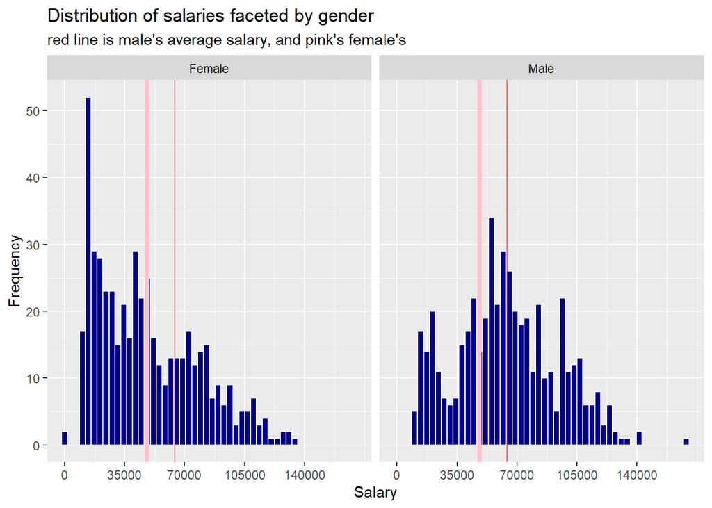

```r
mean_salary_female <- mean(retail.df$Salary[retail.df$Gender =="Female"])
mean_salary_male <- mean(retail.df$Salary[retail.df$Gender =="Male"])


ggplot(data = retail.df, aes(x = Salary))+
  geom_histogram(bins = 50, colour = 'white', fill = 'darkblue')+
  scale_x_continuous(breaks = seq(0,150000,35000))+
  scale_y_continuous(breaks = seq(0,70,10))+
  xlab("Salary")+
  ylab("Frequency")+
  ggtitle("Distribution of salaries faceted by gender")+
  geom_vline(xintercept = mean_salary_female, color = 'pink',size=1.5)+
  geom_vline(xintercept = mean_salary_male, color = 'red', alpha= 0.6)+
  labs(subtitle  = "red line is male's average salary, and pink's female's")+
  facet_wrap(~Gender)
```

*Distribution of salaries for Male is close to a normal distribution, while the distribution of salaries for Female has a heavy tail and positive skewness. As we already have seen in the correlation matrix, males have higher average salaries.*

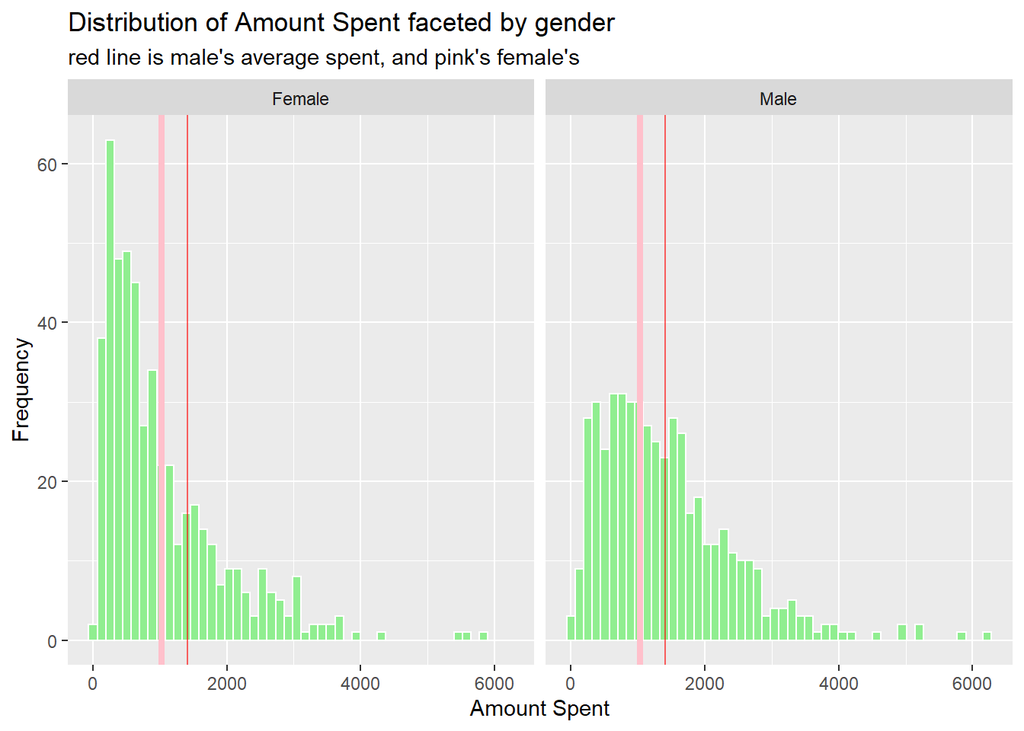

```r
#explain the distributions, males is more normally looking dist, while womens is right skued

mean_AmountSpent_female <- mean(retail.df$AmountSpent[retail.df$Gender =="Female"])
mean_AmountSpent_male <- mean(retail.df$AmountSpent[retail.df$Gender =="Male"])

ggplot(data = retail.df, aes(x = AmountSpent))+
  geom_histogram(bins = 50, colour = 'white', fill = 'lightgreen')+
  scale_x_continuous()+
  scale_y_continuous()+
  xlab("Amount Spent")+
  ylab("Frequency")+
  ggtitle("Distribution of Amount Spent faceted by gender")+
  labs(subtitle  = "red line is male's average spent, and pink's female's")+
  facet_wrap(~Gender)+
  geom_vline(xintercept = mean_AmountSpent_female, color = 'pink',size=1.5)+
  geom_vline(xintercept = mean_AmountSpent_male, color = 'red', alpha= 0.6)
```

```r
#Again explain the distributions, males is more normally looking dist, while womens is right skued
```

*Looking at the distribution of Amount Spent is close to the distribution of Salaries by gender (and as we have seen- positively correlated). Males spend on average 37.3% more than Females.*